# Analysing Geodata in R - YoMos 2026

Yasemin Kukla & Jan Steen

## Geodata

simplified definition:

- Digital information, which is associated with a specific position on earth
- Who did previous work with geodata?
- What kinds of geodata do you know?

## Types of geodata

Vector data

- points, lines or polygons
- e.g. plant observations, streets, political borders
- shapefile, geopackage, geoJSON, …

Raster data

- grid filled with information
- e.g. satellite images, corine land cover
- .tif files

## Using R for analysing geodata

- open source platform
- flexible (statistical) analysis and visualisation
- automation and replication of workflows
- easy sharing of code through git
- various packages for special use cases

## Basic R packages for geodata

- “sf” for vector data
- “terra” for raster data

```r
#install.packages("sf")
library(sf)

#install.packages("terra")
library(terra)
```

Further information:

https://r.geocompx.org/

[figure not shown]

## First steps with vector data

Our example dataset

- OpenStreetMap (download.geofabrik.de/europe/germany/schleswig-holstein.html)
- administrative boundaries (https://geodaten.schleswig-holstein.de/gaialight-sh/_apps/dladownload/dl-vg_kkag.html)

```r
landuse <- st_read("../data/vectordata/landuse.gpkg")
roads <- st_read("../data/vectordata/roads.gpkg")
buildings <- st_read("../data/vectordata/buildings.gpkg")
pois <- st_read("../data/vectordata/pois.gpkg")
```

## Simple features in R

```r
str(landuse)
```

```
Classes 'sf' and 'data.frame':  70 obs. of  5 variables:
 $ osm_id: chr  "76779959" "76920139" "76920144" "18424000" ...
 $ code  : int  7211 7203 7203 7201 7206 7219 7211 7219 7219 7203 ...
 $ fclass: chr  "recreation_ground" "residential" "residential" "forest" ...
 $ name  : chr  NA NA NA NA ...
 $ geom  :sfc_POLYGON of length 70; first list element: List of 1
  ..$ : num [1:29, 1:2] 8.36 8.36 8.36 8.36 8.36 ...
  ..- attr(*, "class")= chr [1:3] "XY" "POLYGON" "sfg"
 - attr(*, "sf_column")= chr "geom"
 - attr(*, "agr")= Factor w/ 3 levels "constant","aggregate",..: NA NA NA NA
  ..- attr(*, "names")= chr [1:4] "osm_id" "code" "fclass" "name"
```

## Subsetting sf objects

Where are benches around us?

```r
library(dplyr)
bench <- pois |> filter(fclass=="bench")
```

[interactive chart not shown]

## Topological queries 1/2

-> How do certain spatial features interact with each other?

Which benches are located in the heathland?

```r
heath <- landuse |> filter(fclass=="heath")

BenchInHeath <- st_intersects(bench,heath)
BenchInHeath <- bench[lengths(BenchInHeath) > 0,]
```

[interactive chart not shown]

## Topological queries 2/2

Finding a place for a short break

```r
AWI <- buildings |> filter(name=="AWI Gästehaus")
```

[interactive chart not shown]

## Topological queries 2/2

Finding a place for a short break

```r
AWI <- buildings |> filter(name=="AWI Gästehaus")

rest <- st_is_within_distance(bench, AWI, dist = 500)
```

[interactive chart not shown]

## Vector calculations 1/2

Mean area of Lister Heathlands

```r
heath$area <- st_area(heath)
mean(heath$area)
```

```
1070587 [m^2]
```

## Vector calculations 2/2

Length of Streets in List

```r
roads$length <- st_length(roads)
mean(roads$length)
```

```
167.7735 [m]
```

[interactive chart not shown]

## First steps with raster data

Raster data is a grid of cells (pixels) where each cell stores a value.

common uses are:

- climate data
- elevation models
- satellite imagery

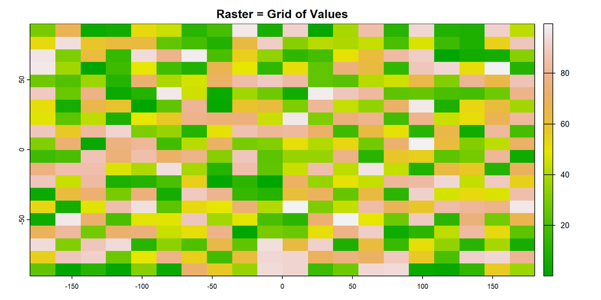

```r
library(terra)
# create simple example raster
r <- rast(nrows=20, ncols=20)
values(r) <- runif(ncell(r), min=0, max=100)

plot(r, col=terrain.colors(100), main="Raster = Grid of Values")
```

## Raster-vector operations

Combine pixel-based data (rasters) with geometry-based data (vectors). Operations let us extract, summarize, or transform raster values using vector shapes.

We will use our example raster:

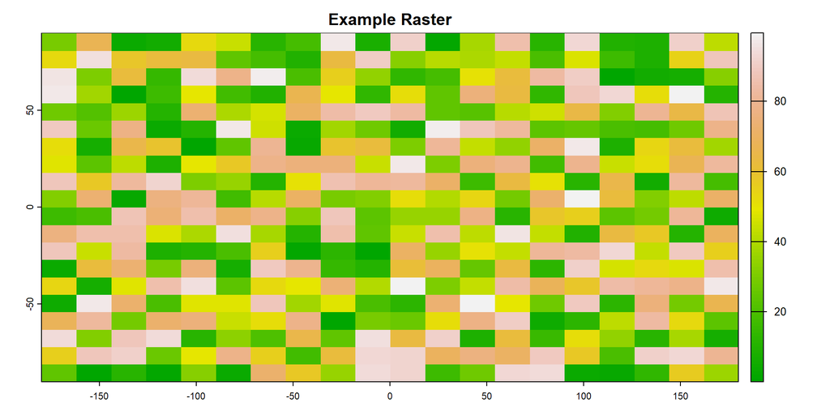

```r
plot(r, col=terrain.colors(100),
     main="Example Raster")
```

And create an example polygon:

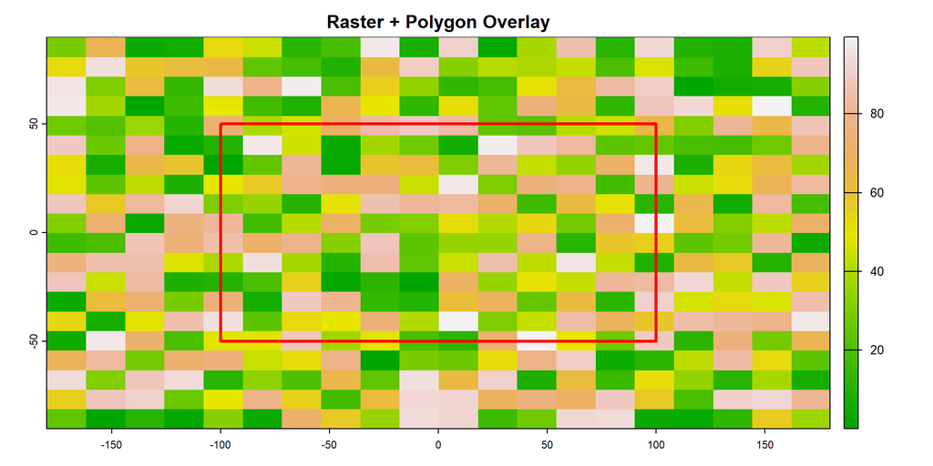

```r
poly <- vect(
  rbind(c(-100, -50), c(-100,  50), c( 100,  50),
        c( 100, -50),c(-100, -50)),
  type = "polygons")
plot(r, col=terrain.colors(100), main="Raster + Polygon Overlay")
lines(poly, col="red", lwd=3)
```

1. Crop raster (clip by extent or polygon)

```r
r_crop <- crop(r, poly)
plot(r_crop, col=terrain.colors(100), main="Cropped Raster")
lines(poly, col="red", lwd=3)
```

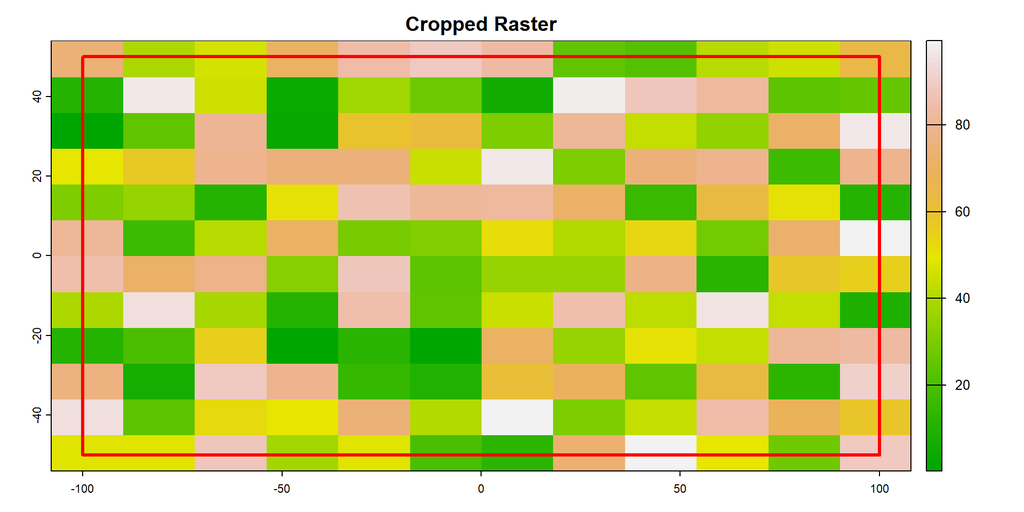

2. Mask (set values outside polygon to NA)

```r
r_mask <- mask(r, poly)
plot(r_mask, col=terrain.colors(100), main="Masked Raster")
lines(poly, col="red", lwd = 3)
```

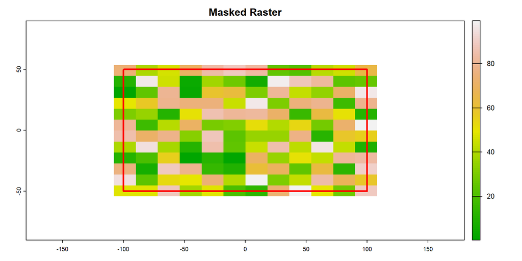

3. Extract values (point or polygon sampling)

```r
vector_points <- vect(
  data.frame(x = c(-120, -30, 40, 100),y = c(-60,  20,  50, -10)),
  geom = c("x", "y"), crs = crs(r))
plot(r, col=terrain.colors(100), main="Raster + Sample Points")
plot(vector_points, add=TRUE, col="blue", pch=16, cex=1.2)
```

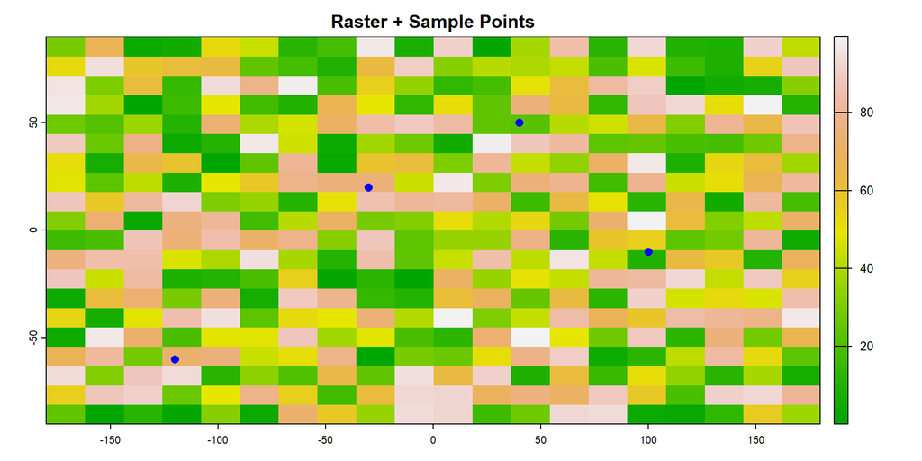

```r
extract(r, vector_points)
```

```
  ID     lyr.1
1  1 71.796112
2  2 74.722306
3  3 21.991911
4  4  9.010452
```

4. Zonal statistics (summarize raster values within polygons)

```r
extract(r, poly, fun=mean, na.rm=TRUE)
```

```
  ID    lyr.1
1  1 51.72544
```

```r
extract(r, poly, fun=max, na.rm=TRUE)
```

```
  ID    lyr.1
1  1 99.39579
```

```r
extract(r, poly, fun=min, na.rm=TRUE)
```

```
  ID     lyr.1
1  1 0.1995192
```

## Map projections

- 2 dimensional image of the 3 dimensional earth
- maps can be either true in Area, shape, or distances
- EPSG code defines the projection

## Map projections

- 2 dimensional image of the 3 dimensional earth
- maps can be either true in Area, shape, or distances
- EPSG code defines the projection

[figure not shown]

Mercator projection (https://en.wikipedia.org/wiki/List_of_map_projections)

## Projections in R

- R does not project ‘on the fly’
- we have to check projections before performing calculations

```r
bench
```

```
Simple feature collection with 102 features and 4 fields
Geometry type: POINT
Dimension:     XY
Bounding box:  xmin: 8.353212 ymin: 54.99054 xmax: 8.440994 ymax: 55.03772
Geodetic CRS:  WGS 84
First 10 features:
       osm_id code fclass name                      geom
1   900938620 2902  bench <NA>  POINT (8.38903 55.00508)
2  1340550406 2902  bench <NA> POINT (8.387352 55.03769)
3  1340550462 2902  bench <NA>  POINT (8.38757 55.03772)
4  1349069604 2902  bench <NA> POINT (8.425952 55.01204)
5  1349069605 2902  bench <NA> POINT (8.426574 55.01232)
6  1349069607 2902  bench <NA> POINT (8.427784 55.01288)
7  1349069608 2902  bench <NA> POINT (8.428407 55.01317)
8  1349069609 2902  bench <NA> POINT (8.428935 55.01343)
9  1349069610 2902  bench <NA> POINT (8.429779 55.01381)
10 1349069611 2902  bench <NA> POINT (8.431562 55.01456)
```

## Reproject in R

Reproject Vector data

```r
st_transform(x, st_crs(y))      ## use another sf object
st_transform(x, "EPSG:4326")    ## use an epsg code
```

Reproject Raster data

```r
project(x, y)                   ## use another object
project(x, 4326)                ## use an epsg code
```

adding missing information

```r
crs(x) <- "EPSG:4326"
```